# Classification

QDA allows for quadratic boundaries and is slightly more flexible than LDA. However, even with this added flexibility, QDA still cannot model the intricate spiral structure well. While it slightly improves over LDA, it still misses many of the curved class transitions.

We fit a Naive Bayes classifier to the training data and visualize its decision regions.

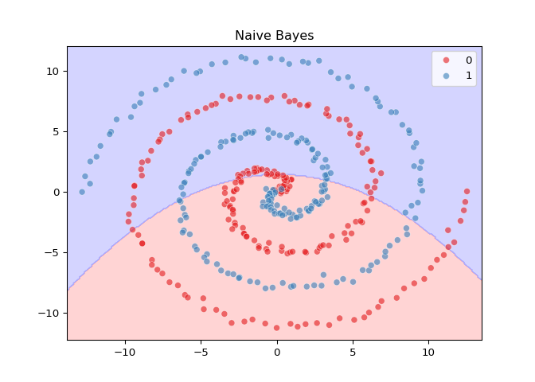

```python
# Fit Naive Bayes model
nb = GaussianNB()
nb.fit(X_train, y_train);
plot_boundary(nb, X, y, "Naive Bayes")
```

We evaluate the performance of the kNN algorithm across a range of $k$ values.

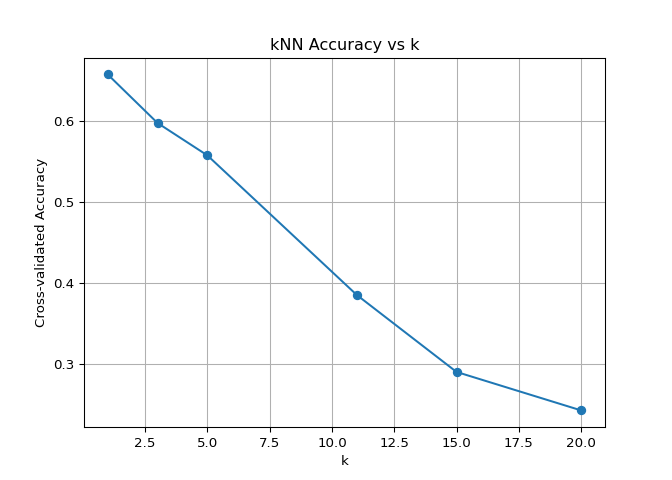

```python
# Fit kNN for multiple k
k_vals = [1, 3, 5, 11, 15, 20]
k_scores = []

for k in k_vals:
    knn = KNeighborsClassifier(n_neighbors=k)
    acc = cross_val_score(knn, X, y, cv=10).mean()
    k_scores.append(acc)

plt.plot(k_vals, k_scores, marker='o');
plt.xlabel("k");
plt.ylabel("Cross-validated Accuracy");
plt.title("kNN Accuracy vs k");
plt.grid(True)
plt.show()
```

From the plot, we identify the value of $k$ that yields the highest accuracy.

```python
best_k = k_vals[np.argmax(k_scores)]
```

The kNN model with the optimal $k=1$ value is able to flexibly adapt to the complex non-linear class structure of the spiral dataset.

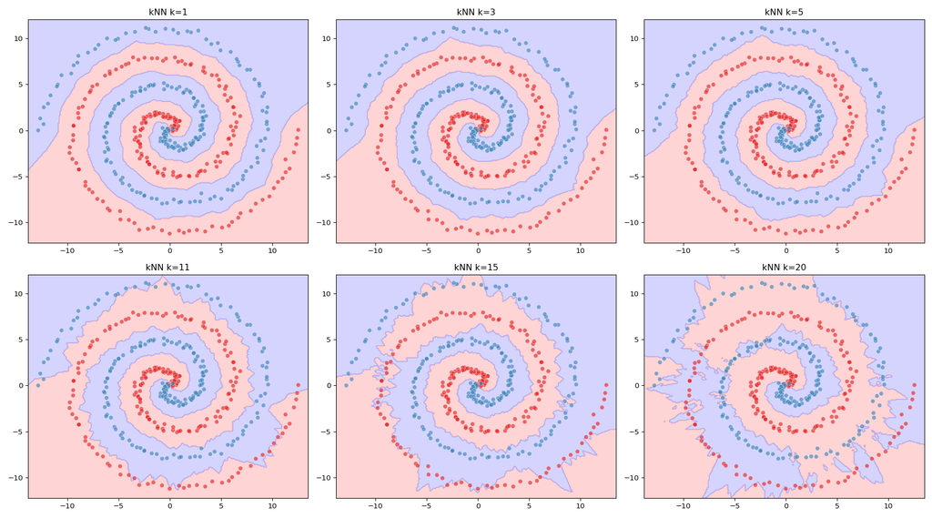

```python
# Plot all decision boundaries for different k
fig, axes = plt.subplots(2, 3, figsize=(18, 10))
from matplotlib.colors import ListedColormap

for ax, k in zip(axes.flat, k_vals):
    knn_k = KNeighborsClassifier(n_neighbors=k)
    knn_k.fit(X_train, y_train);

    h = 0.1
    x_min, x_max = X[:, 0].min() - 1, X[:, 0].max() + 1
    y_min, y_max = X[:, 1].min() - 1, X[:, 1].max() + 1
    xx, yy = np.meshgrid(np.arange(x_min, x_max, h),
                         np.arange(y_min, y_max, h))
    Z = knn_k.predict(np.c_[xx.ravel(), yy.ravel()])
    Z = Z.reshape(xx.shape)

    ax.contourf(xx, yy, Z, cmap=ListedColormap(['#FFAAAA', '#AAAAFF']), alpha=0.5);
    sns.scatterplot(x=X[:, 0], y=X[:, 1], hue=y, palette="Set1", ax=ax, legend=False, alpha=0.6);
    ax.set_title(f"kNN k={k}");

plt.tight_layout()
plt.show()
```

From the plot, we identify the value of $k$ that yields the highest accuracy.

The kNN model with the optimal $k=1$ value is able to flexibly adapt to the complex non-linear class structure of the spiral dataset.

We compared all five classifiers on the held-out $30\%$ test set using accuracy and AUC.

```python
# Final model comparison
knn = KNeighborsClassifier(n_neighbors=best_k)
models = {
    "Logistic": logit,
    "LDA": lda,
    "QDA": qda,
    "Naive Bayes": nb,
    f"kNN (k={best_k})": knn
}

results = []
for name, model in models.items():
    model.fit(X_train, y_train);
    pred = model.predict(X_test);
    prob = model.predict_proba(X_test)[:, 1] if hasattr(model, "predict_proba") else pred;
    acc = accuracy_score(y_test, pred);
    auc = roc_auc_score(y_test, prob);
    cm = confusion_matrix(y_test, pred);
    results.append((name, acc, auc, cm));

summary = pd.DataFrame([(r[0], r[1], r[2]) for r in results], columns=["Model", "Accuracy", "AUC"])
print(summary)
```

```
##          Model  Accuracy       AUC
## 0     Logistic  0.516667  0.641944
## 1          LDA  0.516667  0.641667
## 2          QDA  0.608333  0.613333
## 3  Naive Bayes  0.583333  0.608611
## 4    kNN (k=1)  0.983333  0.983333
```